# Unit 2 Project

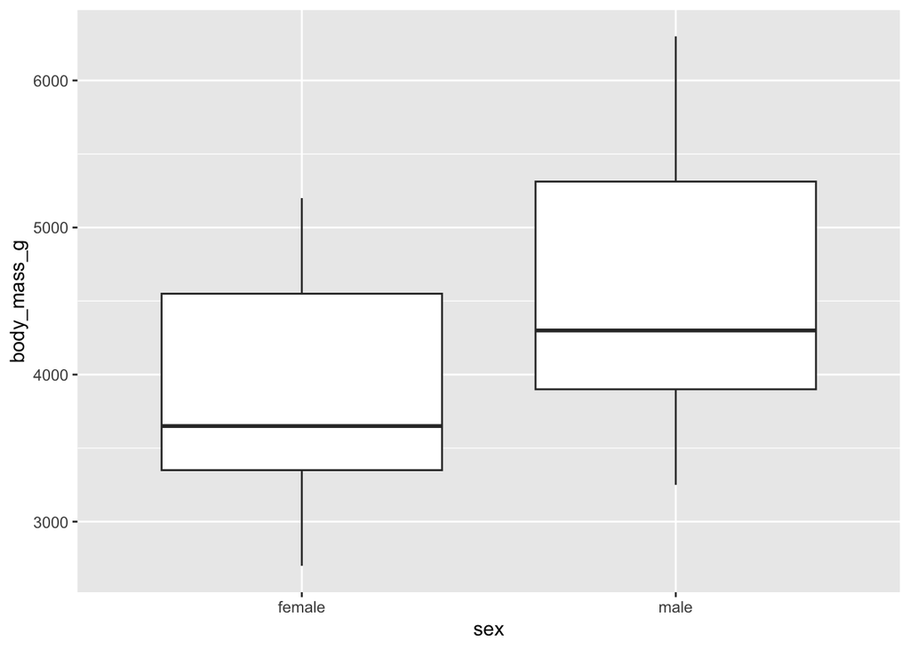

```r
# Do males and females differ? Answer: In general, yes, males tend to be larger in body mass
ggplot(penguins, aes(x = sex, y = body_mass_g)) +
  geom_boxplot()
```

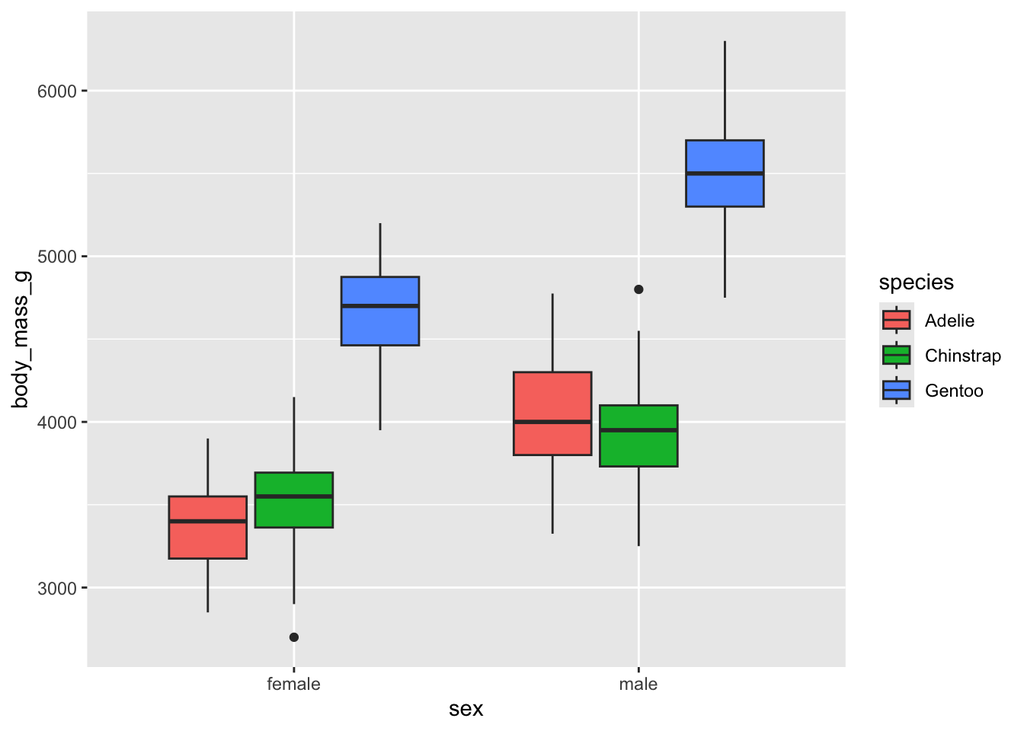

```r
# Does adding fill = species to the aesthetics (aes()) help readability? Answer: Yes, instead of 2 boxplots, there are 6 that are color coded and separated by species and sex. There are also indicated outliers.
ggplot(penguins, aes(x = sex, y = body_mass_g, fill= species)) +
  geom_boxplot()
```

#Q4

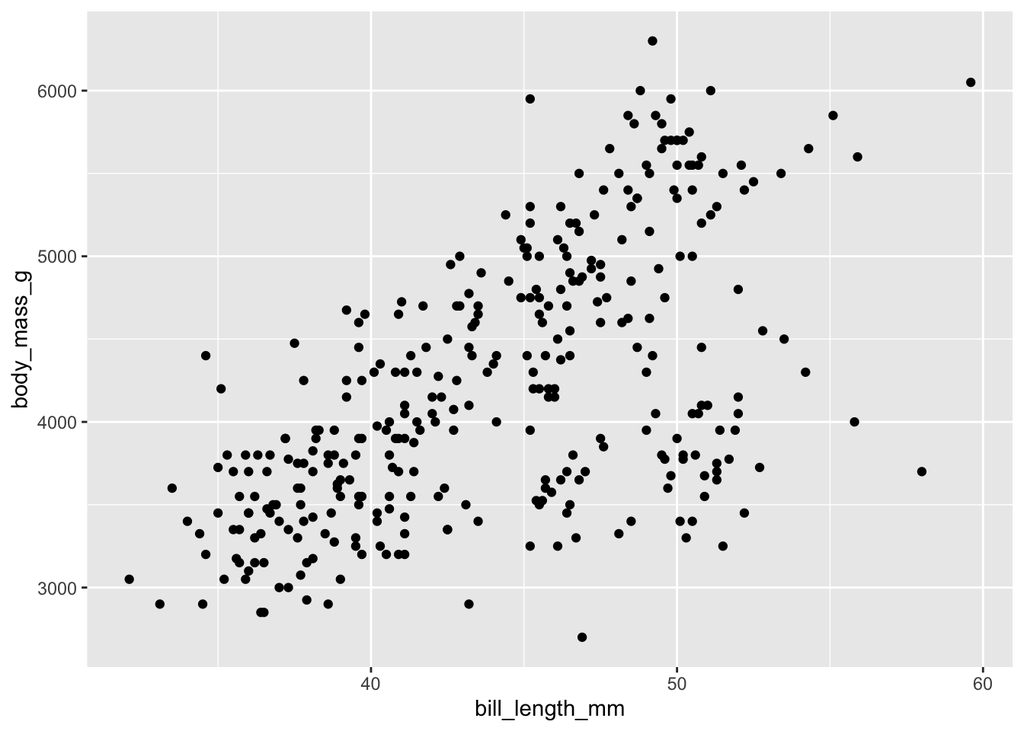

```r
# Is the relationship positive, negative, or unclear? Answer: The relationship is positive or more likely unclear. The points go in one general direction from the bottom to top, but still have many points that remain below the "positive" direction.
ggplot(penguins, aes(x=bill_length_mm, y= body_mass_g)) +
  geom_point()
```

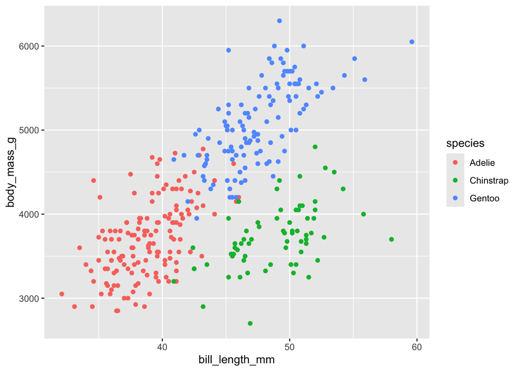

```r
# Color the plot by species (color = species in aes()). Does that change your interpretation? It does, the relationship is positive for each species(Chinstrap moves more towards unclear), but the distinction helps make it clearer to understand.
ggplot(penguins, aes(x=bill_length_mm, y= body_mass_g, color = species)) +
  geom_point()
```

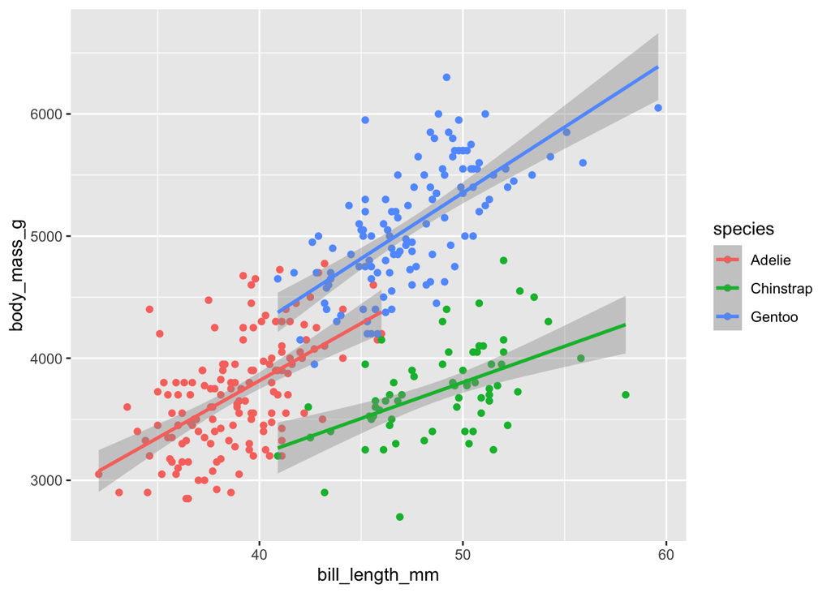

```r
# Does the line fit the data well after adding geom_smooth(method = "lm")? Answer: yes, there are three lines that fit each species and describe a positive relationship for each species (except for Chinstrap which still has many points far from the line)
ggplot(penguins, aes(x=bill_length_mm, y= body_mass_g, color = species)) +
  geom_point() +
  geom_smooth(method = "lm")
```

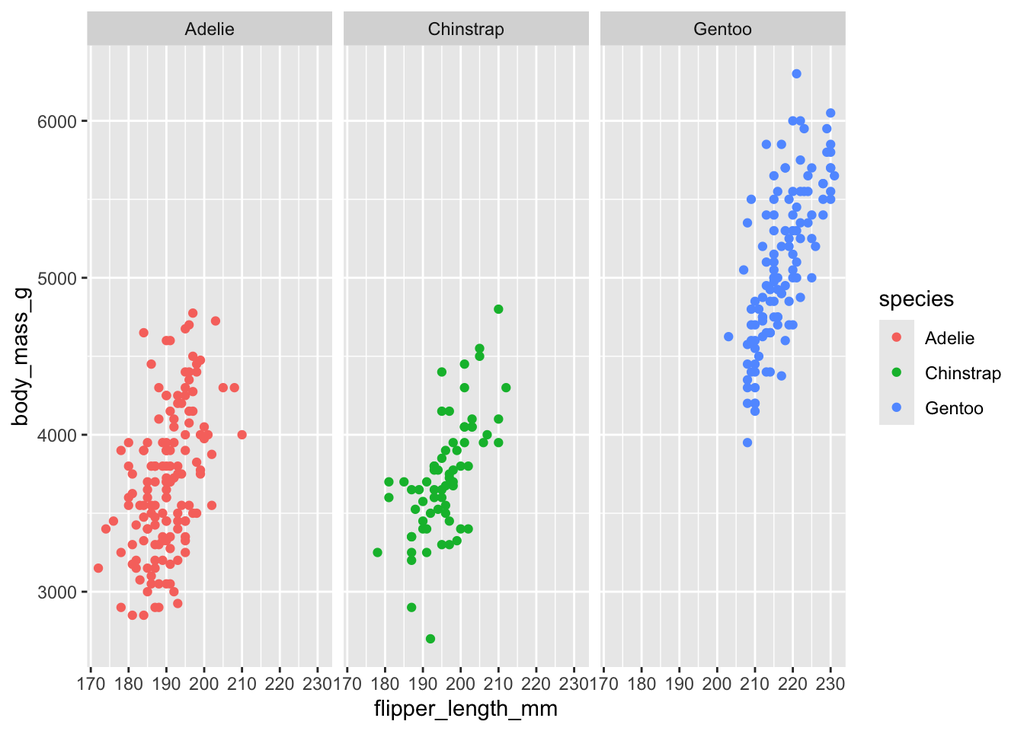

```r
#Q5
# Which species shows the strongest relationship? Answer: Gentoo has the strongest relationship
ggplot(penguins, aes(x = flipper_length_mm, y = body_mass_g, color = species)) +
  geom_point() +
  facet_wrap(~species)
```

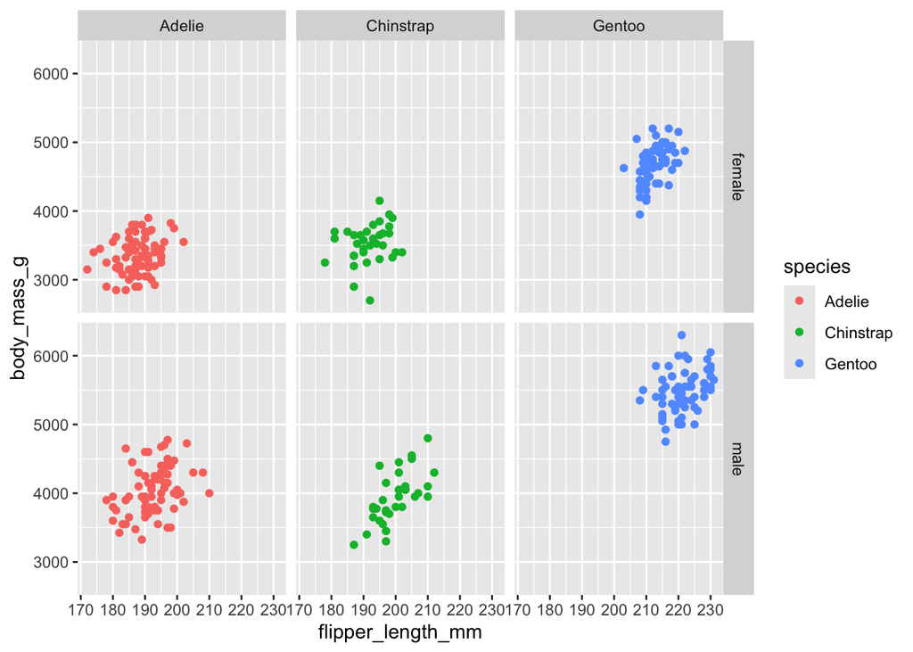

```r
# What patterns appear? Answer: Females have relatively smaller body masses and flipper length compared to males across all species. The positive relationship is less visible.
ggplot(penguins, aes(x = flipper_length_mm, y = body_mass_g, color = species)) +
  geom_point() +
  facet_grid(sex~species)
```

#Q6

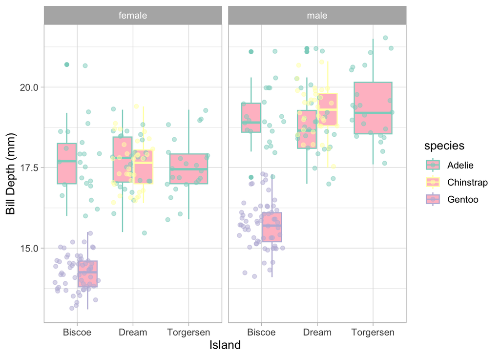

```r
ggplot(penguins, aes(x = island, y = bill_depth_mm,  color = species)) +
  geom_boxplot(fill = "pink") +
  geom_jitter (width = 0.4, alpha = 0.5) +
  facet_wrap(~sex) +
  labs(x= "Island", y= "Bill Depth (mm)") +
  theme_light(base_size = 12) +
  scale_color_brewer(palette = "Set3")
```

#Q7 # The most fun/interesting part was Q6 and choosing colors from the sets and seeing what colors existed/registered. The most challenging part was remembering which function # did what, specifically for the color and theme and figuring out the purpose of x any y in labs vs setting it in aes() . Also one of the plot types include geom_scatter(), which appears to be nonexistent, which was confusing.

#Lecture 07

```r
penguins_messy <- read.csv("penguins_messy.csv")
```

#Q1

```r
# This command detects if the string "adelie" is present within the datasets species category. Species include "adelie", "gentoo" and "chinstrap", which returns TRUE if "adelie" is present and FALSE if anything else.
str_detect(penguins_messy$species_messy, "adelie")
```

```
##   [1]  TRUE  TRUE  TRUE  TRUE  TRUE  TRUE  TRUE  TRUE  TRUE  TRUE  TRUE  TRUE
##  [13]  TRUE  TRUE  TRUE  TRUE  TRUE  TRUE  TRUE  TRUE  TRUE  TRUE  TRUE  TRUE
##  [25]  TRUE  TRUE  TRUE  TRUE  TRUE  TRUE  TRUE  TRUE  TRUE  TRUE  TRUE  TRUE
##  [37]  TRUE  TRUE  TRUE  TRUE  TRUE  TRUE  TRUE  TRUE  TRUE  TRUE  TRUE  TRUE
##  [49]  TRUE  TRUE  TRUE  TRUE  TRUE  TRUE  TRUE  TRUE  TRUE  TRUE  TRUE  TRUE
##  [61]  TRUE  TRUE  TRUE  TRUE  TRUE  TRUE  TRUE  TRUE  TRUE  TRUE  TRUE  TRUE
##  [73]  TRUE  TRUE  TRUE  TRUE  TRUE  TRUE  TRUE  TRUE  TRUE  TRUE  TRUE  TRUE
##  [85]  TRUE  TRUE  TRUE  TRUE  TRUE  TRUE  TRUE  TRUE  TRUE  TRUE  TRUE  TRUE
##  [97]  TRUE  TRUE  TRUE  TRUE  TRUE  TRUE  TRUE  TRUE  TRUE  TRUE  TRUE  TRUE
## [109]  TRUE  TRUE  TRUE  TRUE  TRUE  TRUE  TRUE  TRUE  TRUE  TRUE  TRUE  TRUE
## [121]  TRUE  TRUE  TRUE  TRUE  TRUE  TRUE  TRUE  TRUE  TRUE  TRUE  TRUE  TRUE
## [133]  TRUE  TRUE  TRUE  TRUE  TRUE  TRUE  TRUE  TRUE  TRUE  TRUE  TRUE  TRUE
## [145]  TRUE  TRUE  TRUE  TRUE  TRUE  TRUE  TRUE  TRUE FALSE FALSE FALSE FALSE
## [157] FALSE FALSE FALSE FALSE FALSE FALSE FALSE FALSE FALSE FALSE FALSE FALSE
## [169] FALSE FALSE FALSE FALSE FALSE FALSE FALSE FALSE FALSE FALSE FALSE FALSE
## [181] FALSE FALSE FALSE FALSE FALSE FALSE FALSE FALSE FALSE FALSE FALSE FALSE
## [193] FALSE FALSE FALSE FALSE FALSE FALSE FALSE FALSE FALSE FALSE FALSE FALSE
## [205] FALSE FALSE FALSE FALSE FALSE FALSE FALSE FALSE FALSE FALSE FALSE FALSE
## [217] FALSE FALSE FALSE FALSE FALSE FALSE FALSE FALSE FALSE FALSE FALSE FALSE
## [229] FALSE FALSE FALSE FALSE FALSE FALSE FALSE FALSE FALSE FALSE FALSE FALSE
## [241] FALSE FALSE FALSE FALSE FALSE FALSE FALSE FALSE FALSE FALSE FALSE FALSE
## [253] FALSE FALSE FALSE FALSE FALSE FALSE FALSE FALSE FALSE FALSE FALSE FALSE
## [265] FALSE FALSE FALSE FALSE FALSE FALSE FALSE FALSE FALSE FALSE FALSE FALSE
## [277] FALSE FALSE FALSE FALSE FALSE FALSE FALSE FALSE FALSE FALSE FALSE FALSE
## [289] FALSE FALSE FALSE FALSE FALSE FALSE FALSE FALSE FALSE FALSE FALSE FALSE
## [301] FALSE FALSE FALSE FALSE FALSE FALSE FALSE FALSE FALSE FALSE FALSE FALSE
## [313] FALSE FALSE FALSE FALSE FALSE FALSE FALSE FALSE FALSE FALSE FALSE FALSE
## [325] FALSE FALSE FALSE FALSE FALSE FALSE FALSE FALSE FALSE FALSE FALSE FALSE
## [337] FALSE FALSE FALSE FALSE FALSE FALSE FALSE FALSE
```

```r
# This command replaces question marks(?) with nothing, essentially deleting the question marks present in the M/f for the sex category of the dataset.
str_replace_all(penguins_messy$sex_messy, "\\?", "")
```

```
##   [1] "M" "f" "f" NA  "f" "M" "f" "M" NA  NA  NA  NA  "f" "M" "M" "f" "f" "M"
##  [19] "f" "M" "f" "M" "f" "M" "M" "f" "M" "f" "f" "M" "f" "M" "f" "M" "f" "M"
##  [37] "M" "f" "f" "M" "f" "M" "f" "M" "f" "M" "M" NA  "f" "M" "f" "M" "f" "M"
##  [55] "f" "M" "f" "M" "f" "M" "f" "M" "f" "M" "f" "M" "f" "M" "f" "M" "f" "M"
##  [73] "f" "M" "f" "M" "f" "M" "f" "M" "f" "M" "f" "M" "f" "M" "M" "f" "M" "f"
##  [91] "f" "M" "f" "M" "f" "M" "f" "M" "f" "M" "f" "M" "f" "M" "f" "M" "f" "M"
## [109] "f" "M" "f" "M" "f" "M" "f" "M" "f" "M" "f" "M" "f" "M" "f" "M" "f" "M"
## [127] "f" "M" "f" "M" "f" "M" "f" "M" "f" "M" "f" "M" "f" "M" "f" "M" "f" "M"
## [145] "f" "M" "M" "f" "f" "M" "f" "M" "f" "M" "f" "M" "M" "f" "f" "M" "f" "M"
## [163] "f" "M" "f" "M" "f" "M" "f" "M" "f" "M" "M" "f" "f" "M" "f" "M" NA  "M"
## [181] "f" "M" "M" "f" "f" "M" "f" "M" "f" "M" "f" "M" "f" "M" "f" "M" "M" "f"
## [199] "f" "M" "f" "M" "f" "M" "f" "M" "f" "M" "f" "M" "f" "M" "f" "M" "f" "M"
## [217] "f" "M" NA  "M" "f" "M" "f" "M" "M" "f" "f" "M" "f" "M" "f" "M" "f" "M"
## [235] "f" "M" "f" "M" "f" "M" "f" "M" "f" "M" "f" "M" "f" "M" "M" "f" "f" "M"
## [253] "f" "M" "f" "M" NA  "M" "f" "M" "f" "M" "f" "M" "f" "M" "f" "M" NA  "M"
## [271] "f" NA  "f" "M" "f" "M" "f" "M" "M" "f" "M" "f" "f" "M" "f" "M" "f" "M"
## [289] "f" "M" "f" "M" "M" "f" "f" "M" "f" "M" "f" "M" "f" "M" "f" "M" "f" "M"
## [307] "f" "M" "f" "M" "M" "f" "f" "M" "f" "M" "M" "f" "M" "f" "f" "M" "f" "M"
## [325] "M" "f" "f" "M" "f" "M" "f" "M" "f" "M" "M" "f" "M" "f" "f" "M" "f" "M"
## [343] "M" "f"
```

```r
# This command cuts and collapses repeated whitespace within the island dataset names.
str_squish(penguins_messy$island_messy)
```

```
##   [1] "Torgersen" "Torgersen" "Torgersen" "Torgersen" "Torgersen" "Torgersen"
##   [7] "Torgersen" "Torgersen" "Torgersen" "Torgersen" "Torgersen" "Torgersen"
##  [13] "Torgersen" "Torgersen" "Torgersen" "Torgersen" "Torgersen" "Torgersen"
##  [19] "Torgersen" "Torgersen" "BIS-COE"   "BIS-COE"   "BIS-COE"   "BIS-COE"
##  [25] "BIS-COE"   "BIS-COE"   "BIS-COE"   "BIS-COE"   "BIS-COE"   "BIS-COE"
##  [31] "Dream"     "Dream"     "Dream"     "Dream"     "Dream"     "Dream"
##  [37] "Dream"     "Dream"     "Dream"     "Dream"     "Dream"     "Dream"
##  [43] "Dream"     "Dream"     "Dream"     "Dream"     "Dream"     "Dream"
##  [49] "Dream"     "Dream"     "BIS-COE"   "BIS-COE"   "BIS-COE"   "BIS-COE"
##  [55] "BIS-COE"   "BIS-COE"   "BIS-COE"   "BIS-COE"   "BIS-COE"   "BIS-COE"
##  [61] "BIS-COE"   "BIS-COE"   "BIS-COE"   "BIS-COE"   "BIS-COE"   "BIS-COE"
##  [67] "BIS-COE"   "BIS-COE"   "Torgersen" "Torgersen" "Torgersen" "Torgersen"
##  [73] "Torgersen" "Torgersen" "Torgersen" "Torgersen" "Torgersen" "Torgersen"
##  [79] "Torgersen" "Torgersen" "Torgersen" "Torgersen" "Torgersen" "Torgersen"
##  [85] "Dream"     "Dream"     "Dream"     "Dream"     "Dream"     "Dream"
```

[output cut: 43 more lines]

#Q2

```r
penguins_messy <- penguins_messy %>%
  mutate(valid_id = str_detect(penguins_messy$sample_id, "PAL-[0-9]{3}"))
penguins_messy
```

```
##     species_messy island_messy sex_messy sample_id
## 1          adelie  Torgersen\t         M   PAL-535
## 2          adelie  Torgersen\t        f?   PAL-442
## 3          adelie  Torgersen\t        f?   PAL-668
## 4          adelie  Torgersen\t      <NA>   PAL-920
## 5          adelie  Torgersen\t        f?   PAL-223
## 6          adelie  Torgersen\t         M   PAL-899
## 7          adelie  Torgersen\t        f?   PAL-268
## 8          adelie  Torgersen\t         M   PAL-139
## 9          adelie  Torgersen\t      <NA>   PAL-847
## 10         adelie  Torgersen\t      <NA>   PAL-238
## 11         adelie  Torgersen\t      <NA>   PAL-528
## 12         adelie  Torgersen\t      <NA>   PAL-365
## 13         adelie  Torgersen\t        f?   PAL-662
## 14         adelie  Torgersen\t         M   PAL-890
```

[output cut: 1020 more lines]